# Tipología de Datos

Alejandro Torres

20 de mayo de 2019

## 0.2 1. Descripción del dataset. ¿Por qué es importante y qué pregunta/problema pretende responder?

El conjunto de datos objeto de análisis se ha obtenido a partir de este enlace en Kaggle y está constituido por 12 características (columnas) que presentan 1599 características de vino portigués (filas o registros). Las variables que se disponen son fisicoquímicas (entradas) y sensoriales (la salida) (por ejemplo, no hay datos sobre tipos de uva, marca de vino, precio de venta del vino, etc.).

Entre los campos de este conjunto de datos, encontramos los siguientes:

**fixed.acidity**: Acidez fija, la mayoría de los ácidos relacionados con el vino. Fijos o no volátiles (no se evaporan fácilmente).

**volatile.acidity**: Acidez volátil, la cantidad de ácido acético en el vino, que en niveles demasiado altos puede provocar un sabor desagradable a vinagre.

**citric.acid**: El ácido cítrico se encuentra en pequeñas cantidades, el ácido cítrico puede agregar ‘frescura’ y sabor a los vinos.

**residual.sugar**: azúcar residual, la cantidad de azúcar restante después de que se detiene la fermentación, es raro encontrar vinos con menos de 1 gramo / litro y vinos con más de 45 gramos / litro se consideran dulces.

**chlorides**: Cloruro, la cantidad de sal en el vino.

**free.sulfur.dioxide**: sin dioxido de azufre, la forma sin SO2 existe en equilibrio entre el SO2 molecular (como un gas disuelto) y el ión bisulfito; Previene el crecimiento microbiano y la oxidación del vino.

**total.sulfur.dioxide**: Cantidad total de dióxido de azufre de formas libres y unidas de SO2; en bajas concentraciones, el SO2 es mayormente indetectable en el vino, pero a concentraciones de SO2 libres de más de 50 ppm, el SO2 se hace evidente en la nariz y el sabor del vino.

**density**: La densidad del agua es cercana a la del agua dependiendo del porcentaje de alcohol y de contenido de azúcar.

**pH**: El pH describe qué tan ácido o básico es un vino en una escala de 0 (muy ácido) a 14 (muy básico); La mayoría de los vinos están entre 3-4 en la escala de pH.

**sulphates**: Aditivo de vino sulphatesa que puede contribuir a los niveles de dióxido de azufre (S02), que actúa como un antimicrobiano y antioxidante.  
**alcohol**: alcohol el porcentaje de alcohol del vino .

**quality**: Variable de calidad de salida (basada en datos sensoriales, puntuación entre 0 y 10).

En esta práctica unificaremos los datos, los limpiaremos y trataremos de estimar un modelo que a partir de los datos nos pueda predecir los mejores vinos. Este modelo sera aplicado en el subconjunto de las vinos para ver si existe algun razonmiento entre los datos y la calidad del vino y si se puede exportar a otros países o no.

## 0.3 2. Integración y selección de los datos de interés a analizar.

**fixed.acidity**: Si a la acidez total le quitamos la acidez volátil debida al acético, la diferencia se llama acidez fija. Con lo que si hacemos la operación a la inversa podemos obtener la acidez total.

**volatile.acidity**: La acidez volátil puede oscilar entre 0,2 - 1 gr/L hasta un gramo por litro, una larga crianza en roble pueden situarse alrededor de 0,8 gr/L de acidez volátil sin manifestar sensaciones desagradables.

**citric.acid**: Este ácido desaparece lentamente al ser fermentado por las bacterias. No es muy abundante en la uva.

**residual.sugar**: Se considera vino seco o sin azúcar, cuando ese contenido es inferior a cinco gramos por litro. En función de esta cantidad de azúcares residuales, el vino puede ser: seco, semiseco, semidulce y dulce. Variando de menor a mayor cantidad de azúcar, pudiendo ir desde 1 gramo hasta 200 gramos por litro de azúcar. En los vinos secos en muchas ocasiones no suele sobrepasarse los 2 gramos.

**chlorides**: 1 a 50 mg/L: potasio (agente diurético, efecto que se potencia en los vinos espumosos debido al alto contenido en dióxido de carbono), sodio, hierro, manganeso, boro, nitratos, cloruros y silicio

**free.sulfur.dioxide** :

**total.sulfur.dioxide**: En Europa su valor máximo no suele sobrepasar los 50 miligramos por litro pero en E.E.U.U. puede alcanzar los 350 miligramos por litro con lo que se puede saber si este vino es de buena calidad y se puede exportar.

**density**:

- Vino blanco seco: 0,9880-0,9930 g/mL.
- Vinos tinto seco: 0,9910-0,9950 g/mL.
- Vino espumoso: 0,9890-1,0080 g/mL.
- Vino de licor (moscatel): 1,0500-1,0700 g/mL.
- Mosto: 1,0590-1,1150 g/mL.

**pH**: El pH de la mayoría de los vinos se encuentra en el intervalo de 2,5 a 4,5 , lo que lógicamente recae en el lado ácido de la escala. Un vino con un pH de 2,8 es extremadamente ácido mientras que uno con un pH en torno a 4 es plano, carente de acidez. Los vinos blancos suelen estar entre 3 y 3,3 y la mayoría de los tintos entre 3,3 y 3,6

**sulphates**: Cualquier vino que contiene más de 10 mg por litro de dióxido de azufre deberá indicar en su etiqueta la expresión “Contiene sulfitos”

**alcohol**: La graduación alcohólica que oscila entre los 3,5 y los 15 grados

**quality**:

```r
library(knitr)
library(lubridate)
library(VIM)
library(stringr)
library(psych)
library(pROC)
library(dplyr)
myfile <- "C:\\Users\\prosy\\Documents\\UOC\\Master Ciencia de datos\\Tipología y ciclo de vida de los datos\\Practica 02\\winequality-red.csv"

practica02 <-read.csv(myfile, header = TRUE,sep=",")
length(practica02)
```

```
## [1] 12
```

```r
str(practica02)
```

```
## 'data.frame':    1599 obs. of  12 variables:
##  $ fixed.acidity       : num  7.4 7.8 7.8 11.2 7.4 7.4 7.9 7.3 7.8 7.5 ...
##  $ volatile.acidity    : num  0.7 0.88 0.76 0.28 0.7 0.66 0.6 0.65 0.58 0.5 ...
##  $ citric.acid         : num  0 0 0.04 0.56 0 0 0.06 0 0.02 0.36 ...
##  $ residual.sugar      : num  1.9 2.6 2.3 1.9 1.9 1.8 1.6 1.2 2 6.1 ...
##  $ chlorides           : num  0.076 0.098 0.092 0.075 0.076 0.075 0.069 0.065 0.073 0.071 ...
##  $ free.sulfur.dioxide : num  11 25 15 17 11 13 15 15 9 17 ...
##  $ total.sulfur.dioxide: num  34 67 54 60 34 40 59 21 18 102 ...
##  $ density             : num  0.998 0.997 0.997 0.998 0.998 ...
##  $ pH                  : num  3.51 3.2 3.26 3.16 3.51 3.51 3.3 3.39 3.36 3.35 ...
##  $ sulphates           : num  0.56 0.68 0.65 0.58 0.56 0.56 0.46 0.47 0.57 0.8 ...
##  $ alcohol             : num  9.4 9.8 9.8 9.8 9.4 9.4 9.4 10 9.5 10.5 ...
##  $ quality             : int  5 5 5 6 5 5 5 7 7 5 ...
```

```r
#En este resumen inicial
summary(practica02)
```

```
##  fixed.acidity   volatile.acidity  citric.acid    residual.sugar
##  Min.   : 4.60   Min.   :0.1200   Min.   :0.000   Min.   : 0.900
##  1st Qu.: 7.10   1st Qu.:0.3900   1st Qu.:0.090   1st Qu.: 1.900
##  Median : 7.90   Median :0.5200   Median :0.260   Median : 2.200
##  Mean   : 8.32   Mean   :0.5278   Mean   :0.271   Mean   : 2.539
##  3rd Qu.: 9.20   3rd Qu.:0.6400   3rd Qu.:0.420   3rd Qu.: 2.600
##  Max.   :15.90   Max.   :1.5800   Max.   :1.000   Max.   :15.500
##    chlorides       free.sulfur.dioxide total.sulfur.dioxide
##  Min.   :0.01200   Min.   : 1.00       Min.   :  6.00
##  1st Qu.:0.07000   1st Qu.: 7.00       1st Qu.: 22.00
##  Median :0.07900   Median :14.00       Median : 38.00
##  Mean   :0.08747   Mean   :15.87       Mean   : 46.47
##  3rd Qu.:0.09000   3rd Qu.:21.00       3rd Qu.: 62.00
##  Max.   :0.61100   Max.   :72.00       Max.   :289.00
##     density             pH          sulphates         alcohol
##  Min.   :0.9901   Min.   :2.740   Min.   :0.3300   Min.   : 8.40
##  1st Qu.:0.9956   1st Qu.:3.210   1st Qu.:0.5500   1st Qu.: 9.50
##  Median :0.9968   Median :3.310   Median :0.6200   Median :10.20
##  Mean   :0.9967   Mean   :3.311   Mean   :0.6581   Mean   :10.42
##  3rd Qu.:0.9978   3rd Qu.:3.400   3rd Qu.:0.7300   3rd Qu.:11.10
##  Max.   :1.0037   Max.   :4.010   Max.   :2.0000   Max.   :14.90
##     quality
##  Min.   :3.000
##  1st Qu.:5.000
##  Median :6.000
##  Mean   :5.636
##  3rd Qu.:6.000
##  Max.   :8.000
```

```r
head(practica02)
```

```
##   fixed.acidity volatile.acidity citric.acid residual.sugar chlorides
## 1           7.4             0.70        0.00            1.9     0.076
## 2           7.8             0.88        0.00            2.6     0.098
## 3           7.8             0.76        0.04            2.3     0.092
## 4          11.2             0.28        0.56            1.9     0.075
## 5           7.4             0.70        0.00            1.9     0.076
## 6           7.4             0.66        0.00            1.8     0.075
##   free.sulfur.dioxide total.sulfur.dioxide density   pH sulphates alcohol
## 1                  11                   34  0.9978 3.51      0.56     9.4
## 2                  25                   67  0.9968 3.20      0.68     9.8
## 3                  15                   54  0.9970 3.26      0.65     9.8
## 4                  17                   60  0.9980 3.16      0.58     9.8
## 5                  11                   34  0.9978 3.51      0.56     9.4
## 6                  13                   40  0.9978 3.51      0.56     9.4
##   quality
## 1       5
## 2       5
## 3       5
## 4       6
## 5       5
## 6       5
```

```r
practica02$total.acidity<-practica02$fixed.acidity+practica02$volatile.acidity


# read data
res <- sapply(practica02,class)
kable(data.frame(variables=names(res),clase=as.vector(res)))
```

| variables | clase |
| --- | --- |
| fixed.acidity | numeric |
| volatile.acidity | numeric |
| citric.acid | numeric |
| residual.sugar | numeric |
| chlorides | numeric |
| free.sulfur.dioxide | numeric |
| total.sulfur.dioxide | numeric |
| density | numeric |
| pH | numeric |
| sulphates | numeric |
| alcohol | numeric |
| quality | integer |
| total.acidity | numeric |

Convertimos la variable quality de estadisticas en tipo numérico.

```r
practica02[12] <- lapply(practica02[12], as.numeric)
res <- sapply(practica02,class)
kable(data.frame(variables=names(res),clase=as.vector(res)))
```

| variables | clase |
| --- | --- |
| fixed.acidity | numeric |
| volatile.acidity | numeric |
| citric.acid | numeric |
| residual.sugar | numeric |
| chlorides | numeric |
| free.sulfur.dioxide | numeric |
| total.sulfur.dioxide | numeric |
| density | numeric |
| pH | numeric |
| sulphates | numeric |
| alcohol | numeric |
| quality | numeric |
| total.acidity | numeric |

Se crea una variable nueva llamada total.acidity (acidez total que es la suma de la acidez fija+acidez volatil).

## 0.4 3. Limpieza de los datos.

### 0.4.1 3.1. ¿Los datos contienen ceros o elementos vacíos? ¿Cómo gestionarías cada uno de estos casos?

Se comprueba si hay valores NA y los sustituyo por un campo vacío en este estudio no hay caso NA ni vacíos.

```r
colSums(is.na(practica02))
```

```
##        fixed.acidity     volatile.acidity          citric.acid
##                    0                    0                    0
##       residual.sugar            chlorides  free.sulfur.dioxide
##                    0                    0                    0
## total.sulfur.dioxide              density                   pH
##                    0                    0                    0
##            sulphates              alcohol              quality
##                    0                    0                    0
##        total.acidity
##                    0
```

```r
colSums(practica02=="")
```

```
##        fixed.acidity     volatile.acidity          citric.acid
##                    0                    0                    0
##       residual.sugar            chlorides  free.sulfur.dioxide
##                    0                    0                    0
## total.sulfur.dioxide              density                   pH
##                    0                    0                    0
##            sulphates              alcohol              quality
##                    0                    0                    0
##        total.acidity
##                    0
```

```r
colSums(practica02==0)
```

```
##        fixed.acidity     volatile.acidity          citric.acid
##                    0                    0                  132
##       residual.sugar            chlorides  free.sulfur.dioxide
##                    0                    0                    0
## total.sulfur.dioxide              density                   pH
##                    0                    0                    0
##            sulphates              alcohol              quality
##                    0                    0                    0
##        total.acidity
##                    0
```

Se comprueba si hay valores que en lugar de tener valores vacios o NA tuvieran valor 0.

También se comprueba si hay valores que en lugar de nulos se hubiesen puesto con valor 0, se ve que el ácido cítrico posee 132 registros con valor 0 pero es su valor de acidez con lo que es correcto.

### 0.4.2 3.2. Identificación y tratamiento de valores extremos.

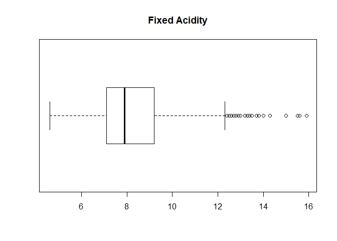

```r
wine.fixed<-boxplot(practica02$fixed.acidity,horizontal = TRUE,main="Fixed Acidity")
```

```r
wine.fixed$out
```

```
##  [1] 12.8 12.8 15.0 15.0 12.5 13.3 13.4 12.4 12.5 13.8 13.5 12.6 12.5 12.8
## [15] 12.8 14.0 13.7 13.7 12.7 12.5 12.8 12.6 15.6 12.5 13.0 12.5 13.3 12.4
## [29] 12.5 12.9 14.3 12.4 15.5 15.5 15.6 13.0 12.7 13.0 12.7 12.4 12.7 13.2
## [43] 13.2 13.2 15.9 13.3 12.9 12.6 12.6
```

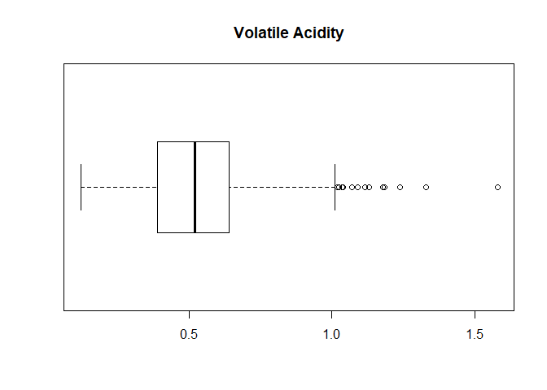

```r
wine.volatile<-boxplot(practica02$volatile.acidity,horizontal = TRUE,main="Volatile Acidity")
```

```r
wine.volatile$out
```

```
##  [1] 1.130 1.020 1.070 1.330 1.330 1.040 1.090 1.040 1.240 1.185 1.020
## [12] 1.035 1.025 1.115 1.020 1.020 1.580 1.180 1.040
```

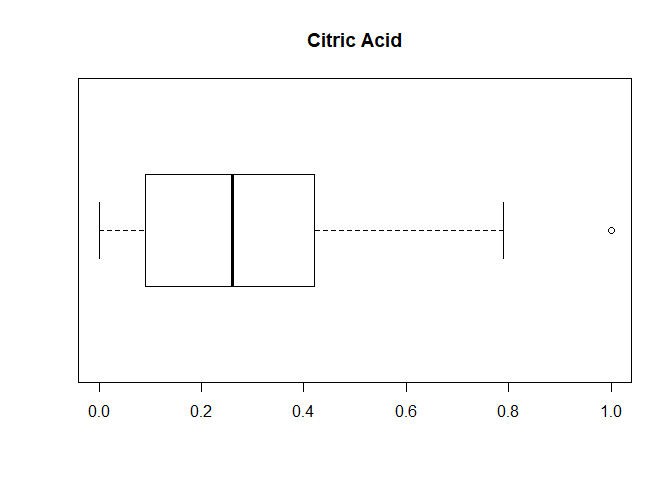

```r
wine.citric<-boxplot(practica02$citric.acid,horizontal = TRUE,main="Citric Acid")
```

```r
wine.citric$out
```

```
## [1] 1
```

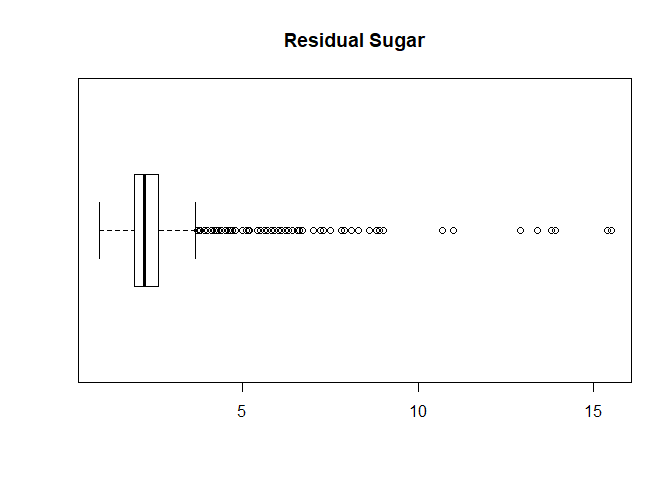

```r
wine.sugar<-boxplot(practica02$residual.sugar,horizontal = TRUE,main="Residual Sugar")
```

```r
wine.sugar$out
```

```
##   [1]  6.10  6.10  3.80  3.90  4.40 10.70  5.50  5.90  5.90  3.80  5.10
##  [12]  4.65  4.65  5.50  5.50  5.50  5.50  7.30  7.20  3.80  5.60  4.00
##  [23]  4.00  4.00  4.00  7.00  4.00  4.00  6.40  5.60  5.60 11.00 11.00
##  [34]  4.50  4.80  5.80  5.80  3.80  4.40  6.20  4.20  7.90  7.90  3.70
##  [45]  4.50  6.70  6.60  3.70  5.20 15.50  4.10  8.30  6.55  6.55  4.60
##  [56]  6.10  4.30  5.80  5.15  6.30  4.20  4.20  4.60  4.20  4.60  4.30
##  [67]  4.30  7.90  4.60  5.10  5.60  5.60  6.00  8.60  7.50  4.40  4.25
##  [78]  6.00  3.90  4.20  4.00  4.00  4.00  6.60  6.00  6.00  3.80  9.00
##  [89]  4.60  8.80  8.80  5.00  3.80  4.10  5.90  4.10  6.20  8.90  4.00
## [100]  3.90  4.00  8.10  8.10  6.40  6.40  8.30  8.30  4.70  5.50  5.50
## [111]  4.30  5.50  3.70  6.20  5.60  7.80  4.60  5.80  4.10 12.90  4.30
## [122] 13.40  4.80  6.30  4.50  4.50  4.30  4.30  3.90  3.80  5.40  3.80
## [133]  6.10  3.90  5.10  5.10  3.90 15.40 15.40  4.80  5.20  5.20  3.75
## [144] 13.80 13.80  5.70  4.30  4.10  4.10  4.40  3.70  6.70 13.90  5.10
## [155]  7.80
```

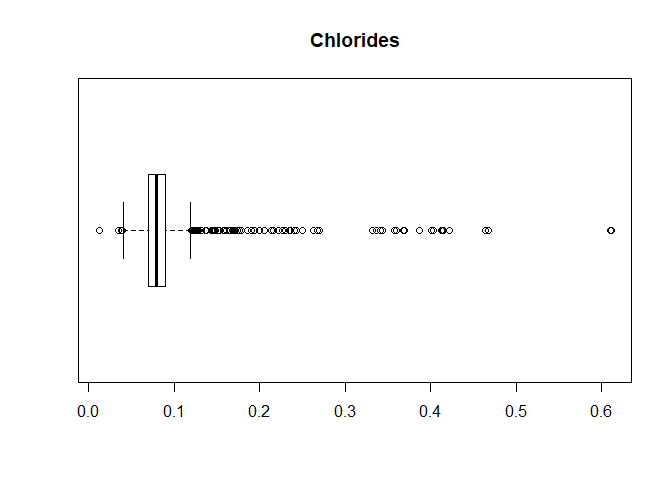

```r
wine.chlorides<-boxplot(practica02$chlorides,horizontal = TRUE,main="Chlorides")
```

```r
wine.chlorides$out
```

```
##   [1] 0.176 0.170 0.368 0.341 0.172 0.332 0.464 0.401 0.467 0.122 0.178
##  [12] 0.146 0.236 0.610 0.360 0.270 0.039 0.337 0.263 0.611 0.358 0.343
##  [23] 0.186 0.213 0.214 0.121 0.122 0.122 0.128 0.120 0.159 0.124 0.122
##  [34] 0.122 0.174 0.121 0.127 0.413 0.152 0.152 0.125 0.122 0.200 0.171
##  [45] 0.226 0.226 0.250 0.148 0.122 0.124 0.124 0.143 0.222 0.039 0.157
##  [56] 0.422 0.034 0.387 0.415 0.157 0.157 0.243 0.241 0.190 0.132 0.126
##  [67] 0.038 0.165 0.145 0.147 0.012 0.012 0.039 0.194 0.132 0.161 0.120
##  [78] 0.120 0.123 0.123 0.414 0.216 0.171 0.178 0.369 0.166 0.166 0.136
##  [89] 0.132 0.132 0.123 0.123 0.123 0.403 0.137 0.414 0.166 0.168 0.415
## [100] 0.153 0.415 0.267 0.123 0.214 0.214 0.169 0.205 0.205 0.039 0.235
## [111] 0.230 0.038
```

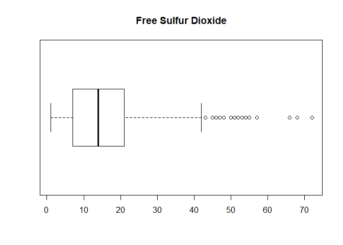

```r
wine.freesulfurdioxide<-boxplot(practica02$free.sulfur.dioxide,horizontal = TRUE,main="Free Sulfur Dioxide")
```

```r
wine.freesulfurdioxide$out
```

```
##  [1] 52 51 50 68 68 43 47 54 46 45 53 52 51 45 57 50 45 48 43 48 72 43 51
## [24] 51 52 55 55 48 48 66
```

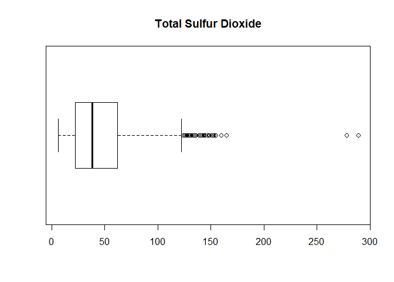

```r
wine.totalsulfurdioxide<-boxplot(practica02$total.sulfur.dioxide,horizontal = TRUE,main="Total Sulfur Dioxide")
```

```r
wine.totalsulfurdioxide$out
```

```
##  [1] 145 148 136 125 140 136 133 153 134 141 129 128 129 128 143 144 127
## [18] 126 145 144 135 165 124 124 134 124 129 151 133 142 149 147 145 148
## [35] 155 151 152 125 127 139 143 144 130 278 289 135 160 141 141 133 147
## [52] 147 131 131 131
```

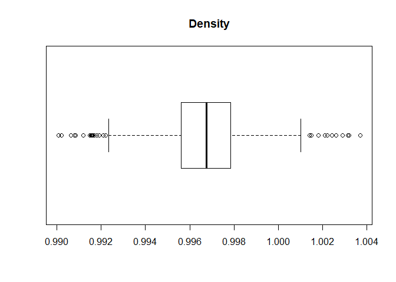

```r
wine.density<-boxplot(practica02$density,horizontal = TRUE,main="Density")
```

```r
wine.density$out
```

```
##  [1] 0.99160 0.99160 1.00140 1.00150 1.00150 1.00180 0.99120 1.00220
##  [9] 1.00220 1.00140 1.00140 1.00140 1.00140 1.00320 1.00260 1.00140
## [17] 1.00315 1.00315 1.00315 1.00210 1.00210 0.99170 0.99220 1.00260
## [25] 0.99210 0.99154 0.99064 0.99064 1.00289 0.99162 0.99007 0.99007
## [33] 0.99020 0.99220 0.99150 0.99157 0.99080 0.99084 0.99191 1.00369
## [41] 1.00369 1.00242 0.99182 1.00242 0.99182
```

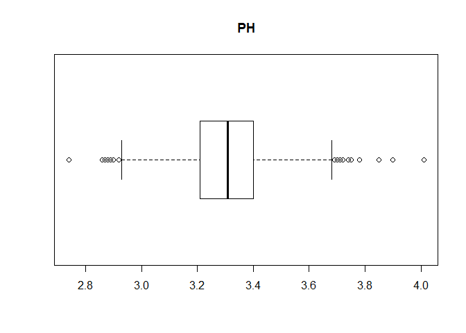

```r
wine.pH<-boxplot(practica02$pH,horizontal = TRUE,main="PH")
```

```r
wine.pH$out
```

```
##  [1] 3.90 3.75 3.85 2.74 3.69 3.69 2.88 2.86 3.74 2.92 2.92 2.92 3.72 2.87
## [15] 2.89 2.89 2.92 3.90 3.71 3.69 3.69 3.71 3.71 2.89 2.89 3.78 3.70 3.78
## [29] 4.01 2.90 4.01 3.71 2.88 3.72 3.72
```

El Ph interviene principalmente en la sensación ácida del vino, pero también afecta al color y conservación del vino. Los valores normales en los vinos oscilan entre 2,5 y 4,5. con lo que no se ve valores salidos de rango.

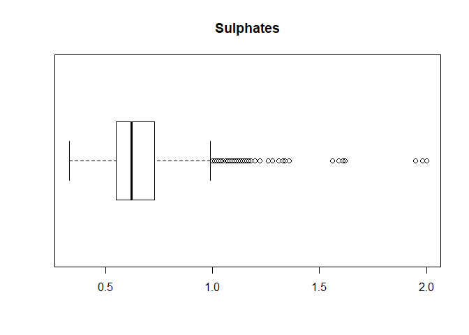

```r
wine.sulphates<-boxplot(practica02$sulphates,horizontal = TRUE,main="Sulphates")
```

```r
wine.sulphates$out
```

```
##  [1] 1.56 1.28 1.08 1.20 1.12 1.28 1.14 1.95 1.22 1.95 1.98 1.31 2.00 1.08
## [15] 1.59 1.02 1.03 1.61 1.09 1.26 1.08 1.00 1.36 1.18 1.13 1.04 1.11 1.13
## [29] 1.07 1.06 1.06 1.05 1.06 1.04 1.05 1.02 1.14 1.02 1.36 1.36 1.05 1.17
## [43] 1.62 1.06 1.18 1.07 1.34 1.16 1.10 1.15 1.17 1.17 1.33 1.18 1.17 1.03
## [57] 1.17 1.10 1.01
```

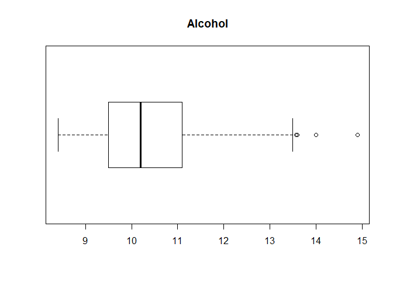

```r
wine.alcohol<-boxplot(practica02$alcohol,horizontal = TRUE,main="Alcohol")
```

```r
wine.alcohol$out
```

```
##  [1] 14.00000 14.00000 14.00000 14.00000 14.90000 14.00000 13.60000
##  [8] 13.60000 13.60000 14.00000 14.00000 13.56667 13.60000
```

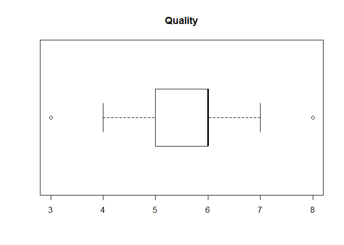

```r
wine.quality<-boxplot(practica02$quality,horizontal = TRUE,main="Quality")
```

```r
wine.quality$out
```

```
##  [1] 8 8 8 8 8 3 8 8 8 3 8 3 8 3 3 8 8 8 8 8 3 3 8 8 3 3 3 8
```

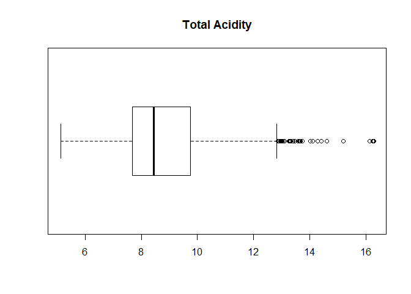

```r
wine.total.acidity<-boxplot(practica02$total.acidity,horizontal = TRUE,main="Total Acidity")
```

```r
wine.total.acidity$out
```

```
##  [1] 13.100 13.100 15.210 15.210 13.060 13.640 13.670 12.890 14.290 14.030
## [11] 12.980 12.960 13.415 13.415 14.410 14.115 14.115 13.300 12.960 13.640
## [21] 12.910 16.285 12.880 13.320 12.870 13.590 13.100 13.250 14.610 16.145
## [31] 16.145 16.245 13.470 13.300 13.470 13.300 13.290 13.660 13.660 13.580
## [41] 16.260 13.730 13.400 13.010 12.990
```

# 1 4. Análisis de los datos.

## 1.1 4.1. Selección de los grupos de datos que se quieren analizar/comparar (planificación de los análisis a aplicar).

A continuación, se seleccionan los grupos dentro de nuestro conjunto de datos que pueden resultar interesantes para analizar y/o comparar. No obstante, como se verá en el apartado consistente en la realización de pruebas estadísticas, no todos se utilizarán.

- alcohol vs. density
- fixed.acidity vs. density
- residual.sugar vs total.sulfur.dioxide
- residual.sugar vs. density
- residual.sugar vs. alcohol
- chlorides vs. density
- chlorides vs. sulphates
- quality vs. alcohol

## 1.2 4.2. Comprobación de la normalidad y homogeneidad de la varianza.

```r
library(nortest)
alpha = 0.05
col.names = colnames(practica02)
for (i in 1:ncol(practica02)) {
  if (i == 1) cat("Variables que no siguen una distribución normal:\n")
  if (is.integer(practica02[,i]) | is.numeric(practica02[,i])) {
    p_val = ad.test(practica02[,i])$p.value
    if (p_val < alpha) {
      cat(col.names[i])
# Format output
    if (i < ncol(practica02) - 1) cat(", ")
    if (i %% 3 == 0) cat("\n")
    }
  }
}
```

```
## Variables que no siguen una distribución normal:
## fixed.acidity, volatile.acidity, citric.acid,
## residual.sugar, chlorides, free.sulfur.dioxide,
## total.sulfur.dioxide, density, pH,
## sulphates, alcohol, quality
## total.acidity
```

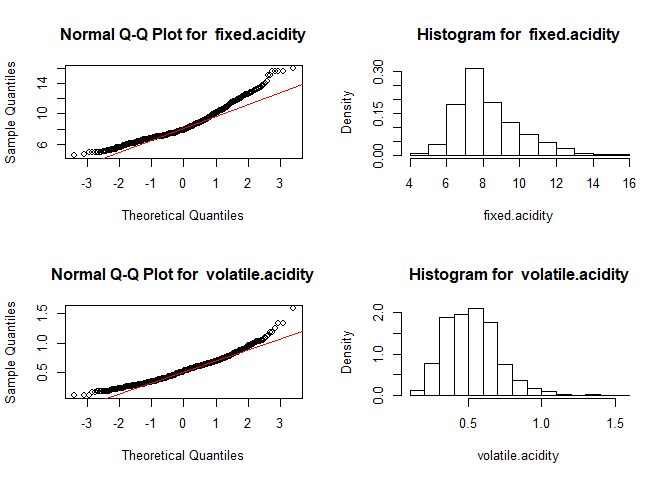

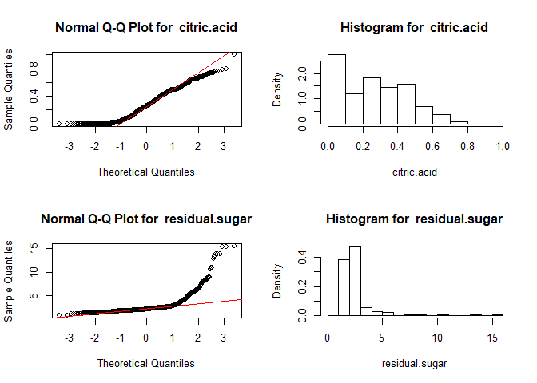

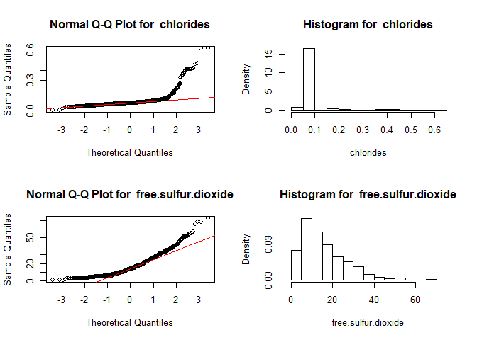

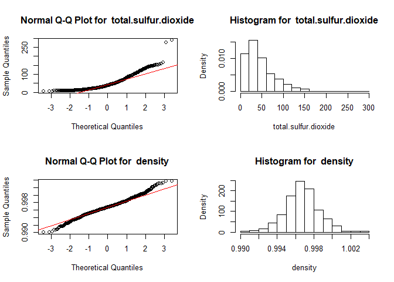

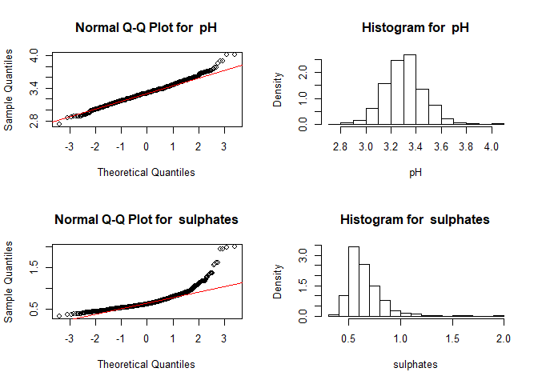

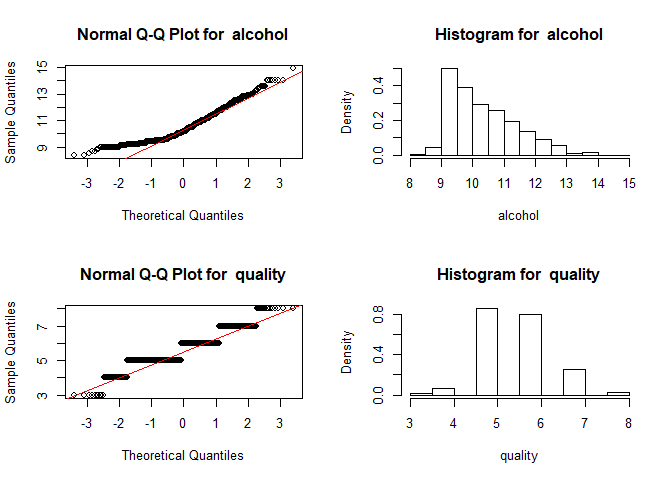

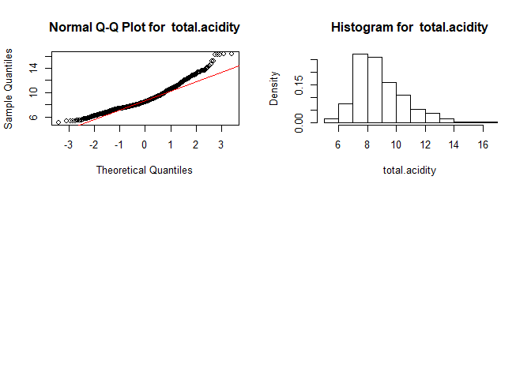

```r
par(mfrow=c(2,2))
for(i in 1:ncol(practica02)) {
if (is.numeric(practica02[,i])){
qqnorm(practica02[,i],main = paste("Normal Q-Q Plot for ",colnames(practica02)[i]))
qqline(practica02[,i],col="red")
hist(practica02[,i],
main=paste("Histogram for ", colnames(practica02)[i]),
xlab=colnames(practica02)[i], freq = FALSE)
}
}
```

El test nos indica que ninguna variable esta normalizada, ya que el p-valor es inferior al coeficiente 0.05, por lo que se puede rechazar la hipotesis nula y entender que no es normal.

Seguidamente, pasamos a estudiar la homogeneidad de varianzas mediante la aplicación de un test de Fligner-Killeen. En este caso, estudiaremos esta homogeneidad en cuanto a los grupos conformados por alcohol vs. density, fixed.acidity vs. density,residual.sugar vs total.sulfur.dioxide, residual.sugar vs. density,residual.sugar vs. alcohol, chlorides vs. density, chlorides vs. sulphates, quality vs. alcohol. En el siguiente test, la hipótesis nula consiste en que ambas varianzas son iguales.

### 1.2.1 alcohol vs. density

```r
fligner.test(alcohol ~ density, data = practica02)
```

```
##
##  Fligner-Killeen test of homogeneity of variances
##
## data:  alcohol by density
## Fligner-Killeen:med chi-squared = 552.97, df = 435, p-value =
## 0.0001043
```

Dado que ambas pruebas resultan en un p-valor inferior al nivel de significancia (<0.05), se rechaza la hipótesis nula de homocedasticidad y se concluye que la variable alcohol presenta varianzas estadísticamente diferentes para los diferentes grupos de density

### 1.2.2 fixed.acidity vs. density

```r
fligner.test(fixed.acidity ~ density, data = practica02)
```

```
##
##  Fligner-Killeen test of homogeneity of variances
##
## data:  fixed.acidity by density
## Fligner-Killeen:med chi-squared = 599.48, df = 435, p-value =
## 2.6e-07
```

Dado que ambas pruebas resultan en un p-valor inferior al nivel de significancia (<0.05), se rechaza la hipótesis nula de homocedasticidad y se concluye que la variable fixed.acidity presenta varianzas estadísticamente diferentes para los diferentes grupos de density

### 1.2.3 residual.sugar vs total.sulfur.dioxide

```r
fligner.test(residual.sugar ~ total.sulfur.dioxide, data = practica02)
```

```
##
##  Fligner-Killeen test of homogeneity of variances
##
## data:  residual.sugar by total.sulfur.dioxide
## Fligner-Killeen:med chi-squared = 328.53, df = 143, p-value <
## 2.2e-16
```

Dado que ambas pruebas resultan en un p-valor inferior al nivel de significancia (<0.05), se rechaza la hipótesis nula de homocedasticidad y se concluye que la variable residual.sugar presenta varianzas estadísticamente diferentes para los diferentes grupos de total.sulfur.dioxide

### 1.2.4 residual.sugar vs. density

```r
fligner.test(residual.sugar ~ density, data = practica02)
```

```
##
##  Fligner-Killeen test of homogeneity of variances
##
## data:  residual.sugar by density
## Fligner-Killeen:med chi-squared = 619.66, df = 435, p-value =
## 1.297e-08
```

Dado que ambas pruebas resultan en un p-valor inferior al nivel de significancia (<0.05), se rechaza la hipótesis nula de homocedasticidad y se concluye que la variable residual.sugar presenta varianzas estadísticamente diferentes para los diferentes grupos de density

### 1.2.5 residual.sugar vs. alcohol

```r
fligner.test(residual.sugar ~ alcohol, data = practica02)
```

```
##
##  Fligner-Killeen test of homogeneity of variances
##
## data:  residual.sugar by alcohol
## Fligner-Killeen:med chi-squared = 126.44, df = 64, p-value =
## 5.458e-06
```

Dado que ambas pruebas resultan en un p-valor inferior al nivel de significancia (<0.05), se rechaza la hipótesis nula de homocedasticidad y se concluye que la variable residual.sugar presenta varianzas estadísticamente diferentes para los diferentes grupos de alcohol

### 1.2.6 chlorides vs. density

```r
fligner.test(chlorides ~ density, data = practica02)
```

```
##
##  Fligner-Killeen test of homogeneity of variances
##
## data:  chlorides by density
## Fligner-Killeen:med chi-squared = 564.92, df = 435, p-value =
## 2.542e-05
```

Dado que ambas pruebas resultan en un p-valor inferior al nivel de significancia (<0.05), se rechaza la hipótesis nula de homocedasticidad y se concluye que la variable chlorides presenta varianzas estadísticamente diferentes para los diferentes grupos de density

### 1.2.7 chlorides vs. sulphates

```r
fligner.test(chlorides ~ sulphates, data = practica02)
```

```
##
##  Fligner-Killeen test of homogeneity of variances
##
## data:  chlorides by sulphates
## Fligner-Killeen:med chi-squared = 195.74, df = 95, p-value =
## 5.735e-09
```

Dado que ambas pruebas resultan en un p-valor inferior al nivel de significancia (<0.05), se rechaza la hipótesis nula de homocedasticidad y se concluye que la variable chlorides presenta varianzas estadísticamente diferentes para los diferentes grupos de sulphates

### 1.2.8 quality vs. alcohol

```r
fligner.test(quality ~ alcohol, data = practica02)
```

```
##
##  Fligner-Killeen test of homogeneity of variances
##
## data:  quality by alcohol
## Fligner-Killeen:med chi-squared = 135.98, df = 64, p-value =
## 4.157e-07
```

Dado que ambas pruebas resultan en un p-valor inferior al nivel de significancia (<0.05), se rechaza la hipótesis nula de homocedasticidad y se concluye que la variable quality presenta varianzas estadísticamente diferentes para los diferentes grupos de alcohol

## 1.3 4.3. Aplicación de pruebas estadísticas para comparar los grupos de datos. En función de los datos y el objetivo del estudio, aplicar pruebas de contraste de hipótesis, correlaciones, regresiones, etc. Aplicar al menos tres métodos de análisis diferentes.

```r
library(Kendall)
# Calcular el coeficiente de correlación
summary(Kendall(practica02$alcohol,practica02$density))
```

```
## Score =  -412718 , Var(Score) = 453856288
## denominator =  1251594
## tau = -0.33, 2-sided pvalue =< 2.22e-16
```

```r
summary(Kendall(practica02$fixed.acidity,practica02$density))
```

```
## Score =  576893 , Var(Score) = 454395168
## denominator =  1261075
## tau = 0.457, 2-sided pvalue =< 2.22e-16
```

```r
summary(Kendall(practica02$residual.sugar,practica02$total.sulfur.dioxide))
```

```
## Score =  126327 , Var(Score) = 452804384
## denominator =  1235290
## tau = 0.102, 2-sided pvalue =< 2.22e-16
```

```r
summary(Kendall(practica02$residual.sugar,practica02$density))
```

```
## Score =  366724 , Var(Score) = 452860096
## denominator =  1238990
## tau = 0.296, 2-sided pvalue =< 2.22e-16
```

```r
summary(Kendall(practica02$residual.sugar,practica02$alcohol))
```

```
## Score =  99181 , Var(Score) = 452122080
## denominator =  1221346
## tau = 0.0812, 2-sided pvalue =3.0994e-06
```

```r
summary(Kendall(practica02$chlorides,practica02$density))
```

```
## Score =  363373 , Var(Score) = 454426752
## denominator =  1262298
## tau = 0.288, 2-sided pvalue =< 2.22e-16
```

```r
summary(Kendall(practica02$chlorides,practica02$sulphates))
```

```
## Score =  17805 , Var(Score) = 454135552
## denominator =  1251512
## tau = 0.0142, 2-sided pvalue =0.40346
```

```r
summary(Kendall(practica02$quality,practica02$alcohol))
```

```
## Score =  382953 , Var(Score) = 389028960
## denominator =  1006798
## tau = 0.38, 2-sided pvalue =< 2.22e-16
```

practica02$alcohol,practica02$density

```r
library(BSDA)
z <- z.test(x = practica02$alcohol, y = practica02$density, # Two samples with normal distribution
            alt = "two.sided",          # Dos colas
            mu = 0,                     # H_0: mu_1 - mu_2 = 0
            sigma.x = sd(practica02$alcohol),     # desviación estándar m
            sigma.y = sd(practica02$density),     # desviación estandar n
            conf.level = 0.95)          # IC: error alpha_a/2 = 0.01/2

z
```

```
##
##  Two-sample z-Test
##
## data:  practica02$alcohol and practica02$density
## z = 353.7, p-value < 2.2e-16
## alternative hypothesis: true difference in means is not equal to 0
## 95 percent confidence interval:
##  9.374003 9.478470
## sample estimates:
##  mean of x  mean of y
## 10.4229831  0.9967467
```

practica02$fixed.acidity,practica02$density

```r
z <- z.test(x = practica02$fixed.acidity, y = practica02$density, # Two samples with normal distribution
            alt = "two.sided",          # Dos colas
            mu = 0,                     # H_0: mu_1 - mu_2 = 0
            sigma.x = sd(practica02$fixed.acidity),     # desviación estándar m
            sigma.y = sd(practica02$density),     # desviación estandar n
            conf.level = 0.95)          # IC: error alpha_a/2 = 0.01/2

z
```

```
##
##  Two-sample z-Test
##
## data:  practica02$fixed.acidity and practica02$density
## z = 168.18, p-value < 2.2e-16
## alternative hypothesis: true difference in means is not equal to 0
## 95 percent confidence interval:
##  7.237552 7.408229
## sample estimates:
## mean of x mean of y
## 8.3196373 0.9967467
```

practica02$residual.sugar,practica02$total.sulfur.dioxide

```r
z <- z.test(x = practica02$residual.sugar, y = practica02$total.sulfur.dioxide, # Two samples with normal distribution
            alt = "two.sided",          # Dos colas
            mu = 0,                     # H_0: mu_1 - mu_2 = 0
            sigma.x = sd(practica02$residual.sugar),     # desviación estándar m
            sigma.y = sd(practica02$total.sulfur.dioxide),     # desviación estandar n
            conf.level = 0.95)          # IC: error alpha_a/2 = 0.01/2

z
```

```
##
##  Two-sample z-Test
##
## data:  practica02$residual.sugar and practica02$total.sulfur.dioxide
## z = -53.351, p-value < 2.2e-16
## alternative hypothesis: true difference in means is not equal to 0
## 95 percent confidence interval:
##  -45.54281 -42.31516
## sample estimates:
## mean of x mean of y
##  2.538806 46.467792
```

practica02$residual.sugar,practica02$density

```r
z <- z.test(x = practica02$residual.sugar, y = practica02$density, # Two samples with normal distribution
            alt = "two.sided",          # Dos colas
            mu = 0,                     # H_0: mu_1 - mu_2 = 0
            sigma.x = sd(practica02$residual.sugar),     # desviación estándar m
            sigma.y = sd(practica02$density),     # desviación estandar n
            conf.level = 0.95)          # IC: error alpha_a/2 = 0.01/2

z
```

```
##
##  Two-sample z-Test
##
## data:  practica02$residual.sugar and practica02$density
## z = 43.735, p-value < 2.2e-16
## alternative hypothesis: true difference in means is not equal to 0
## 95 percent confidence interval:
##  1.472952 1.611166
## sample estimates:
## mean of x mean of y
## 2.5388055 0.9967467
```

practica02$residual.sugar,practica02$alcohol

```r
z <- z.test(x = practica02$residual.sugar, y = practica02$alcohol, # Two samples with normal distribution
            alt = "two.sided",          # Dos colas
            mu = 0,                     # H_0: mu_1 - mu_2 = 0
            sigma.x = sd(practica02$residual.sugar),     # desviación estándar m
            sigma.y = sd(practica02$alcohol),     # desviación estandar n
            conf.level = 0.95)          # IC: error alpha_a/2 = 0.01/2

z
```

```
##
##  Two-sample z-Test
##
## data:  practica02$residual.sugar and practica02$alcohol
## z = -178.38, p-value < 2.2e-16
## alternative hypothesis: true difference in means is not equal to 0
## 95 percent confidence interval:
##  -7.970804 -7.797552
## sample estimates:
## mean of x mean of y
##  2.538806 10.422983
```

practica02$chlorides,practica02$density

```r
z <- z.test(x = practica02$chlorides, y = practica02$density, # Two samples with normal distribution
            alt = "two.sided",          # Dos colas
            mu = 0,                     # H_0: mu_1 - mu_2 = 0
            sigma.x = sd(practica02$chlorides),     # desviación estándar m
            sigma.y = sd(practica02$density),     # desviación estandar n
            conf.level = 0.95)          # IC: error alpha_a/2 = 0.01/2

z
```

```
##
##  Two-sample z-Test
##
## data:  practica02$chlorides and practica02$density
## z = -771.92, p-value < 2.2e-16
## alternative hypothesis: true difference in means is not equal to 0
## 95 percent confidence interval:
##  -0.9115889 -0.9069714
## sample estimates:
##  mean of x  mean of y
## 0.08746654 0.99674668
```

practica02$chlorides,practica02$sulphates

```r
z <- z.test(x = practica02$chlorides, y = practica02$sulphates, # Two samples with normal distribution
            alt = "two.sided",          # Dos colas
            mu = 0,                     # H_0: mu_1 - mu_2 = 0
            sigma.x = sd(practica02$chlorides),     # desviación estándar m
            sigma.y = sd(practica02$sulphates),     # desviación estandar n
            conf.level = 0.95)          # IC: error alpha_a/2 = 0.01/2

z
```

```
##
##  Two-sample z-Test
##
## data:  practica02$chlorides and practica02$sulphates
## z = -129.72, p-value < 2.2e-16
## alternative hypothesis: true difference in means is not equal to 0
## 95 percent confidence interval:
##  -0.5793049 -0.5620597
## sample estimates:
##  mean of x  mean of y
## 0.08746654 0.65814884
```

practica02$quality,practica02$alcohol

```r
z <- z.test(x = practica02$quality, y = practica02$alcohol, # Two samples with normal distribution
            alt = "two.sided",          # Dos colas
            mu = 0,                     # H_0: mu_1 - mu_2 = 0
            sigma.x = sd(practica02$quality),     # desviación estándar m
            sigma.y = sd(practica02$alcohol),     # desviación estandar n
            conf.level = 0.95)          # IC: error alpha_a/2 = 0.01/2

z
```

```
##
##  Two-sample z-Test
##
## data:  practica02$quality and practica02$alcohol
## z = -143.16, p-value < 2.2e-16
## alternative hypothesis: true difference in means is not equal to 0
## 95 percent confidence interval:
##  -4.852497 -4.721424
## sample estimates:
## mean of x mean of y
##  5.636023 10.422983
```

Para obtener un modelo de regresión lineal considerablemente eficiente, lo que haremos será obtener varios modelos de regresión utilizando las variables que estén más correlacionadas, escogeremos el mejor utilizando como criterio aquel que presente un mayor coeficiente de determinación (R2).

```r
modelo1 <- lm(quality~residual.sugar + total.sulfur.dioxide , data = practica02)
modelo2 <- lm(quality~residual.sugar + total.sulfur.dioxide + density , data = practica02)
modelo3 <- lm(quality~residual.sugar+ total.sulfur.dioxide+density+ alcohol, data = practica02)
```

Para los anteriores modelos de regresión lineal múltiple obtenidos, podemos utilizar el coeficiente de determinación para medir la bondad de los ajustes y quedarnos con aquel modelo que mejor coeficiente presente.

```r
# Tabla con los coeficientes de determinación de cada modelo
tabla.coeficientes <- matrix(c(1, summary(modelo1)$r.squared,
2, summary(modelo2)$r.squared,
3, summary(modelo3)$r.squared),
ncol = 2, byrow = TRUE)
colnames(tabla.coeficientes) <- c("Modelo", "R^2")
tabla.coeficientes
```

```
##      Modelo        R^2
## [1,]      1 0.03700825
## [2,]      2 0.07407521
## [3,]      3 0.23959593
```

El mejor modelo para elegir es el 3.

```r
newdata <- data.frame(
residual.sugar=18,
total.sulfur.dioxide=34,
density=0.998,
alcohol=9.2
)
# Predecir el precio
predict(modelo3, newdata)
```

```
##        1
## 5.045182
```